# Terruqueo en X

Análisis de publicaciones en la red social X que cubren seis periodos entre 2016–2026

Fecha de publicación

31 de octubre de 2026

# Introducción

Luego de una clasificación de todos los posts de X que se descargaron (más de 200 mil), nos quedamos con un grupo de **107 340** publicaciones de **X** (antes Twitter). La data analizada solo incluye los post que contienen palabras derivadas de “terruco” y son usados **como insultos**.

Se puede revisar la base de datos completa en el siguiente [link](https://docs.google.com/spreadsheets/d/1hteTKTPTMbSP1_Stdoho3YO6Fe9wGTrD/edit?usp=sharing).

## Seis periodos

Cada post pertenece a un periodo que representa un determinado contexto en el Perú, según la coyuntura de ese entonces.

Cantidad de posts por periodo (solo posts etiquetados como insultos)

| periodo_id | Coyuntura | Rango | Días | Registros | porcentaje |
| --- | --- | --- | --- | --- | --- |
| P1 | Elecciones Generales 2016 | 2016-03-01 a 2016-06-30 | 122 | 6 170 | 5,7% |
| P2 | Vacancia Merino + paro agrario Ica | 2020-11-07 a 2021-01-31 | 86 | 6 232 | 5,8% |
| P3 | Elecciones Generales 2021 | 2021-01-01 a 2021-07-28 | 209 | 31 370 | 29,2% |
| P4 | Represión protestas del sur | 2022-12-07 a 2023-03-31 | 115 | 44 738 | 41,7% |
| P5 | Protestas Jerí / Trvko | 2025-10-15 a 2025-12-31 | 78 | 9 022 | 8,4% |
| P6 | Elecciones 2026 — 2ª vuelta | 2026-03-01 a 2026-06-07 | 99 | 9 808 | 9,1% |
| Total | — | — | 709 | 107 340 | 100,0% |

La represión en las protestas del sur (P4) y las elecciones generales de 2021 (P3) concentraron la mayor cantidad de posts etiquetados como insultos. Solo estos dos periodos representan el 70% de toda el universo analizado.

## Cómo se clasificó

La clasificación se apoyó en un prompt con **once reglas**.

La regla más frecuente **el blanco no tiene que estar nombrado** cubre acusaciones genéricas como “los zurdos”, manifestantes, “ongs”.

Se puede revisar cada regla en el siguiente [link](https://docs.google.com/spreadsheets/d/1ffC1HrfvTNMnB2IXM-nHrd527fzBy0semaYtkN2PtcU/edit).

## Diccionario de datos

| Campo | Qué es |
| --- | --- |
| periodo_id / periodo_texto / periodo_rango_fechas | Coyuntura política de la búsqueda (P1–P6) |
| keyword | Palabra o expresión usada en la búsqueda para el scrapeo |
| fecha_publicacion / fecha | Día del post |
| created_at / created_local | Fecha UTC original y convertida al horario de Lima. |
| text | Texto del post/publicación. |
| post_type | Tipo de post: original, reply (respuesta) o quote (cita). |
| author_handle / author_id / author_name | Identidad de la cuenta/perfil de la cuenta al momento del scrapeo. |
| author_followers / following / verified / description / location | Datos generales del autor de la publicación. |
| likes, retweets, replies, quote_count, views | Métricas de interacción y alcance. |
| hashtags, mentions, conversation_id, in_reply_handle | Datos adicionales de la publicación. |
| source | Plataforma de publicación (Twitter for Android, Web App, etc.). |
| is_terruqueo | Etiqueta del clasificador: en este grupo todos los posts etiquetados como insultos. |
| regla / regla_nombre / regla_descripcion_prompt | Regla de clasificación aplicada |
| justificacion | Explicación breve del modelo para entender por qué usó esa etiqueta. |

# 1. Los periodos del terruqueo

Para cada periodo, el gráfico muestra **cuántos posts hay por día calendario** (`fecha`).

[interactive chart not shown]

Si juntamos todos los periodos (cada uno con diferentes rangos de fechas), podemos observar que los días con mayor cantidad de publicaciones pertenecen a “la represión en las protestas del sur.

Se puede ver los datos del gráfico en el siguiente [googlesheet](https://docs.google.com/spreadsheets/d/1Ub7KJ1z02rdA_KVVJ8WdteWBMSXug6qjGwYxuKSYv_w/edit).

## P1 — Elecciones Generales 2016

Rango de fechas: **2016-03-01 a 2016-06-30**. En este periodo hay **6 170** posts (El día con mayor cantidad de posts fue el **10 de abril de 2016**, con 259 publicaciones).

[interactive chart not shown]

Los tres días con más posts. En cada uno, tres ejemplos (cuentas distintas, las de mayor alcance ese día):

- **(domingo, 10 de abril de 2016)** — 259 posts
  - [@zorrein](https://x.com/zorrein): «La Terruca se quedó en el camino, hasta la vista Baby 🔫» — [ver post](https://x.com/zorrein/status/719366972744593408)
  - [@martinhidalgo](https://x.com/martinhidalgo): «- Vero ganó en Cusco. - Es que Cusco está lleno de "terrucos". *Pasan Año Nuevo en Cusco.» — [ver post](https://x.com/martinhidalgo/status/719289677098979332)
  - [@contracultural](https://x.com/contracultural): «-Horrible la gente desinformadáaa que vota por la terruca de Mendoza, ellos no han vivido lo que… -Calla, mierda. https://t.co/TPhqVCcF0I» — [ver post](https://x.com/contracultural/status/719289356301778944)
- **(sábado, 9 de abril de 2016)** — 194 posts
  - [@rlopezaliaga1](https://x.com/rlopezaliaga1): «La Mendoza tiene lista llena de terrucos y abortistas! Aparte, su modelo económico ya fracasó en Venezuela y Cuba..! https://t.co/D9do4ObdZj» — [ver post](https://x.com/rlopezaliaga1/status/719018430729482240)
  - [@JBCPERU](https://x.com/JBCPERU): «Que comiencen maldiciendo a Paniagua,Toledo,caviares y CIDH. Ellos liberaron terrucos q siguen asolando al país. https://t.co/06v7bsfogU» — [ver post](https://x.com/JBCPERU/status/718941747750047744)
  - [@alvarosarco](https://x.com/alvarosarco): «@RPPNoticias No es coherente repudiar atentado terrorista y por otro lado tener como candidato al Congreso a un pro terruco. Roja mentirosa!» — [ver post](https://x.com/alvarosarco/status/718876085908291585)
- **(miércoles, 16 de marzo de 2016)** — 187 posts
  - [@evelinorcon](https://x.com/evelinorcon): «Marisa Glave dice rechazar la violencia, pero no quitarán de su lista de candidatos a Gilvonio. Coherencia por favor! #TerrorismoNuncaMas» — [ver post](https://x.com/evelinorcon/status/710079448528379904)
  - [@meiermq](https://x.com/meiermq): «Es obvio que quien odia tanto a quienes acabaron con el terrorismo, simpatice con terrucos. Lógica elemental https://t.co/ffZgMhVa2G» — [ver post](https://x.com/meiermq/status/710090660804558849)
  - [@AlcortaLourdes](https://x.com/AlcortaLourdes): «Abel Gilvonio familiar d terrucos dice:A Keiko no le preguntan Xsu papa ni Xsu mama,niX el pasado.Solo le preguntan Xsus propuestas Q tal?» — [ver post](https://x.com/AlcortaLourdes/status/710157070952112128)

Se puede ver los datos del gráfico en el siguiente [googlesheet](https://docs.google.com/spreadsheets/d/1sdyotrZtr4E0UbA-GmooM63E3b6aCpyWia2gZz_0pAU/edit).

## P2 — Vacancia Merino + paro agrario Ica

Rango de fechas: **2020-11-07 a 2021-01-31**. En este periodo hay **6 232** posts (El día con mayor cantidad de posts fue el **15 de noviembre de 2020**, con 518 publicaciones).

[interactive chart not shown]

Los tres días con más posts. En cada uno, tres ejemplos (cuentas distintas, las de mayor alcance ese día):

- **(domingo, 15 de noviembre de 2020)** — 518 posts
  - [@marita_molina4](https://x.com/marita_molina4): «No olvidaremos que @OmarChehadeMoya y @CarmenOmonte votaron a favor de la defensora de terroristas. #TerrorismoNuncaMas» — [ver post](https://x.com/marita_molina4/status/1328169370380546050)
  - [@VozLiberal](https://x.com/VozLiberal): «Prefiero mil veces a Manuel Merino que a Rocío Silva Santisteban. El Perú dio un salto al vacío. Gracias pulpines. Gracias marchantes y tontos útiles de la izquierda. Gracias prensa basura. Estamos en…» — [ver post](https://x.com/VozLiberal/status/1328094678726696960)
  - [@varenitas](https://x.com/varenitas): «@Vero_Mendoza_F Tú callada, terruca oportunista. Intentaste utilizar las marchas para tu conveniencia pero en Cusco te quitaron la careta.» — [ver post](https://x.com/varenitas/status/1328043778947624964)
- **(miércoles, 2 de diciembre de 2020)** — 448 posts
  - [@alvarosarco](https://x.com/alvarosarco): «Según reportera de Willax en Ica, la orden del exministro Rubén Vargas a la policía fue no enfrentar a los manifestantes que destruían los bienes públicos y privados y que bloqueaban la Panamericana S…» — [ver post](https://x.com/alvarosarco/status/1334329752988028928)
  - [@JohnZV10](https://x.com/JohnZV10): «Milagros Leiva es la periodista mas desinformada que hay en el Peru. Se acaba de enterar por Benedicto Jimenez ( al menos eso aparento ) que Lescano tiene una hermana terruca. Realmente no sabia lo de…» — [ver post](https://x.com/JohnZV10/status/1334341184022589444)
  - [@elhigadodmarita](https://x.com/elhigadodmarita): «Estos creen que nos hemos caído del palto. "Justo" cuando un admirador de terroristas es presidente ¿qué sucede? "se captura" a miembros de SL y toda la prensa allí, de caja de resonancia, para limpia…» — [ver post](https://x.com/elhigadodmarita/status/1334116973320564741)
- **(lunes, 16 de noviembre de 2020)** — 443 posts
  - [@Uncafecommie](https://x.com/Uncafecommie): «Martha Chávez: ‘’no apoyo a esta nueva lista pro terruco’’ Todo el Perú: VOTA CTM» — [ver post](https://x.com/Uncafecommie/status/1328423549367967745)
  - [@elhigadodmarita](https://x.com/elhigadodmarita): «Hoy resulta que Sagasti solo pidió un "certificado de rehén" a un terruco. Decir eso es insultar la inteligencia y capacidad de discernimiento de los peruanos e insultar la memoria de los asesinados y…» — [ver post](https://x.com/elhigadodmarita/status/1328476619909062657)
  - [@margamedonzac](https://x.com/margamedonzac): «Francisco Sagasti admirador del MRTA sería el próximo presidente del Perú, esto es una burla a nuestras Fuerzas Armadas, los millones de muertos en manos terroristas no sirvieron de nada. El camarada …» — [ver post](https://x.com/margamedonzac/status/1328407150536904707)

Se puede ver los datos del gráfico en el siguiente [googlesheet](https://docs.google.com/spreadsheets/d/1iA2sCZIQiq3azIpHgAmhdbRVcvW2xquuWvL9wyYYPGg/edit).

## P3 — Elecciones Generales 2021

Rango de fechas: **2021-01-01 a 2021-07-28**. En este periodo hay **31 370** posts (El día con mayor cantidad de posts fue el **18 de mayo de 2021**, con 552 publicaciones).

[interactive chart not shown]

Los tres días con más posts. En cada uno, tres ejemplos (cuentas distintas, las de mayor alcance ese día):

- **(martes, 18 de mayo de 2021)** — 552 posts
  - [@Mauriciomulder](https://x.com/Mauriciomulder): «Formidable y contundente columna televisiva de @BetoASaber que resume con precisión el golpe de estado contínuo que comenzó con el Lagarto en el 2019 y esta planificado para terminar dandole el poder …» — [ver post](https://x.com/Mauriciomulder/status/1394843391469490181)
  - [@aaronsalomong](https://x.com/aaronsalomong): «Jorge Salas Arenas, defensor de terrucos, debe largarse del JNE.» — [ver post](https://x.com/aaronsalomong/status/1394851189188173830)
  - [@CJTJTCMnmagnttI](https://x.com/CJTJTCMnmagnttI): «El HIJODPUTA Jorge Salas del @JNE_Peru dejó pasar a todos los terrucos de Castillo. Maldito desgraciado.» — [ver post](https://x.com/CJTJTCMnmagnttI/status/1394842126664470528)
- **(lunes, 24 de mayo de 2021)** — 518 posts
  - [@JackyMc10](https://x.com/JackyMc10): «“Camarada Lucia Mariana Alvites Sosa a tus 36 años ya eres toda una tuca”. https://t.co/ygFMJajHh5» — [ver post](https://x.com/JackyMc10/status/1397007808021815296)
  - [@mariobryceofic](https://x.com/mariobryceofic): «La matanza en el Vraem de parte de terroristas de sendero luminoso amenazando a la población a no votar por Keiko es la prueba de lo que significan éstos de PL. #NoAlComunismoEnElPeru #TerrorismoNunca…» — [ver post](https://x.com/mariobryceofic/status/1396887492045979651)
  - [@jimmybussol](https://x.com/jimmybussol): «Y ayer el asqueroso de Guillen en el debate, nos quiso dar catedra en seguridad ciudadana, no es mas que un simple pro terruco miserable! https://t.co/TDv8DAxjdn» — [ver post](https://x.com/jimmybussol/status/1396937828697772038)
- **(sábado, 17 de abril de 2021)** — 473 posts
  - [@el_analista2020](https://x.com/el_analista2020): «Al terruco se le terruquea. Sin miedo.» — [ver post](https://x.com/el_analista2020/status/1383471303932350465)
  - [@MarthaChavezC](https://x.com/MarthaChavezC): «Los "amiguis" de la emerretista Lori Berenson y del No a la Revocatoria de Villarán.» — [ver post](https://x.com/MarthaChavezC/status/1383508682692980737)
  - [@LucianoRevoredo](https://x.com/LucianoRevoredo): «Aparecieron los troles terrucos. Cientos muy agresivos. Llenando de odio las redes» — [ver post](https://x.com/LucianoRevoredo/status/1383492785756512264)

Se puede ver los datos del gráfico en el siguiente [googlesheet](https://docs.google.com/spreadsheets/d/1L5_G1uhHIUHIztMV4DdmuSsHaHQ2uwJaa41vis-DJvA/edit).

## P4 — Represión protestas del sur

Rango de fechas: **2022-12-07 a 2023-03-31**. En este periodo hay **44 738** posts (El día con mayor cantidad de posts fue el **17 de diciembre de 2022**, con 1 263 publicaciones).

[interactive chart not shown]

Los tres días con más posts. En cada uno, tres ejemplos (cuentas distintas, las de mayor alcance ese día):

- **(sábado, 17 de diciembre de 2022)** — 1 263 posts
  - [@rodgonzalezl](https://x.com/rodgonzalezl): «No estás en condiciones de exigir nada terruco psicopata. Las vas a pagar todas» — [ver post](https://x.com/rodgonzalezl/status/1604150037839216640)
  - [@VirgiDArbulu](https://x.com/VirgiDArbulu): «Guillermo Bermejo debe estar con diarrea viendo la conferencia de prensa de Palacio de Gobierno. Con los terrucos no se negocia! 🇵🇪 El Perú se respeta, carajo! 🇵🇪» — [ver post](https://x.com/VirgiDArbulu/status/1604126285684424706)
  - [@ValeriaBersaken](https://x.com/ValeriaBersaken): «#URGENTE Fuentes de Inteligencia señalan que @GuilleBermejoR se encuentra en estos momentos en el distrito de Puente Piedra coordinando más actos subversivos con emisarios de los Quispe Palomino. ¿Que…» — [ver post](https://x.com/ValeriaBersaken/status/1604195215132205058)
- **(sábado, 21 de enero de 2023)** — 1 104 posts
  - [@ValeriaBersaken](https://x.com/ValeriaBersaken): «#URGENTE ‼️‼️Policía captura a subversivos que se encontraban en la @UNMSM_ se les incauta hondas, quetes de pasta básica, cientos de avellanas y hasta dinamita #TerrorismoNuncaMas , como en los 90s n…» — [ver post](https://x.com/ValeriaBersaken/status/1616823472419704832)
  - [@Rivar_2021](https://x.com/Rivar_2021): «YA LOS PODEMOS TERRUQUEAR O TODAVÍA? QUE va mal pensados LA GASOLINA era para cocinar a leña y lograr bastante fuego, O NO @julianaoxenford que dices @NicolasLucar cuál será la opinión DE ROSA MARÍA P…» — [ver post](https://x.com/Rivar_2021/status/1616876986072178689)
  - [@Futbolero_Crema](https://x.com/Futbolero_Crema): «Lo de Puno ya rebasa todo lógica, se debe investigar a ese Gobernador Regional y el ejecutivo declarar el Estado de Sitio, esa gente se está suicidando, nada bueno va a salir de quemar su propia ciuda…» — [ver post](https://x.com/Futbolero_Crema/status/1616936657189588992)
- **(jueves, 15 de diciembre de 2022)** — 1 062 posts
  - [@PasquinDeM](https://x.com/PasquinDeM): «Estaban desfilando los terrucos cuando de pronto se escucha un rugido eran cientos de chicas policías! He llorado de alegría viendo a nuestra PNP saliendo a defender su país. VIVA EL PERÚ 🇵🇪 #Terroris…» — [ver post](https://x.com/PasquinDeM/status/1603517608719892481)
  - [@llama_pituca](https://x.com/llama_pituca): «No quieres más masacre? -No salgas en estado de emergencia y toque de queda a quemar aeropuertos e instituciones privadas y públicas, pegar y reventar la cabeza a los policías y FFAA. No quieres masac…» — [ver post](https://x.com/llama_pituca/status/1603579561991700481)
  - [@LuisPesantes](https://x.com/LuisPesantes): «GRACIAS @PoliciaPeru ¡Somos Libres; Seámoslo Siempre! 🇵🇪 — 📍Chao, Virú, La Libertad. #TerrorismoNuncaMas https://t.co/DdcAN9wXWi» — [ver post](https://x.com/LuisPesantes/status/1603511464358055936)

Se puede ver los datos del gráfico en el siguiente [googlesheet](https://docs.google.com/spreadsheets/d/1mm_vqhzKk_Jh0xBccx1RXYWq9RKjqmzTnM3QeiUfZik/edit).

## P5 — Protestas Jerí / Trvko

Rango de fechas: **2025-10-15 a 2025-12-31**. En este periodo hay **9 022** posts (El día con mayor cantidad de posts fue el **16 de octubre de 2025**, con 512 publicaciones).

[interactive chart not shown]

Los tres días con más posts. En cada uno, tres ejemplos (cuentas distintas, las de mayor alcance ese día):

- **(jueves, 16 de octubre de 2025)** — 512 posts
  - [@DanteBobadilla](https://x.com/DanteBobadilla): «A esta tombita los cobardes malvivientes de la marcha de vándalos la empujó con moto y todo haciéndola caer al suelo. Y cuando la turba se le iba encima tuvo el tino de sacar su arma de reglamento y a…» — [ver post](https://x.com/DanteBobadilla/status/1979006470747246722)
  - [@FlordelosMilag6](https://x.com/FlordelosMilag6): «Decirle TERRUCO a un TERRUCO, NO se llama "terruqueo", se llama DIFUSIÓN DE LA VERDAD. 100 policías heridos, unos 20 TERRORISTAS heridos. Cómo así paso? Porque la @PoliciaPeru NO se ha defendido como …» — [ver post](https://x.com/FlordelosMilag6/status/1979046805909144011)
  - [@Pusycat2017](https://x.com/Pusycat2017): «TERRUCOS EN ACCIÓN (foto Milagros Leiva) #MilagrosLeivaEntrevista Atención @PoliciaPeru @josejeriore @FlorPabloMedina TERRUCA #MarchaNacional #TerrorismoNuncaMas Mario Vizcarra #TomaLaCalle Sigrid Baz…» — [ver post](https://x.com/Pusycat2017/status/1979006116362088571)
- **(sábado, 25 de octubre de 2025)** — 438 posts
  - [@jorgevillenal](https://x.com/jorgevillenal): «Decirle Terruco a los Terrucos y a sus simpatizantes, es un acto de valor necesario y patriótico.» — [ver post](https://x.com/jorgevillenal/status/1982191949080646091)
  - [@alexmazzini_](https://x.com/alexmazzini_): «Sale el terruco y entrará la ignorante. Nos libramos de Guillermo Bermejo y entrará Zaira Arias. De cagada en cagada.» — [ver post](https://x.com/alexmazzini_/status/1982245092791287850)
  - [@el_analista2020](https://x.com/el_analista2020): «Qué maravillosa Marcha por la Paz hoy en el centro de Lima. Qué bien se siente ser de derecha y estar siempre en el lado correcto de la historia. Mientras la izquierda llora a sus terrucos en la cárce…» — [ver post](https://x.com/el_analista2020/status/1982223268934266925)
- **(miércoles, 15 de octubre de 2025)** — 424 posts
  - [@MGoblinciano](https://x.com/MGoblinciano): «Asi se comportan los rojos de este pais, luego se ponen a llorar cuando les llamas terrucos, chupen pinga rojos ctm #peru #marcha #generacionZ https://t.co/Pv0WoxOrrz» — [ver post](https://x.com/MGoblinciano/status/1978537813445329211)
  - [@KellyRo_97](https://x.com/KellyRo_97): «🚨LA MARCHA FUE UN COMPLETO FRACASO!!! Sin embargo, es tiempo que regrese la BESTIA EL ROCHABUS, versión 2025. Todos esos terrukos cobardes carcosos tienen su punto débil, el AGUA. Plaza San Martin Gen…» — [ver post](https://x.com/KellyRo_97/status/1978674526893289633)
  - [@LARESISTENCIA_P](https://x.com/LARESISTENCIA_P): «Nuestro respeto para el presidente Jerí. Da la cara y pone el pecho ante manifestantes y delincuentes. No es pusilánime ni huevera. Hacía falta alguien así en Palacio En la marcha abundan terrucos, zu…» — [ver post](https://x.com/LARESISTENCIA_P/status/1978684641973268600)

Se puede ver los datos del gráfico en el siguiente [googlesheet](https://docs.google.com/spreadsheets/d/1nDEWcO47twA9BYlmwhUoMQyG-mQCBuGW7ah2ev405Z0/edit).

## P6 — Elecciones 2026 — 2ª vuelta

Rango de fechas: **2026-03-01 a 2026-06-07**. En este periodo hay **9 808** posts (El día con mayor cantidad de posts fue el **7 de junio de 2026**, con 754 publicaciones).

[interactive chart not shown]

Los tres días con más posts. En cada uno, tres ejemplos (cuentas distintas, las de mayor alcance ese día):

- **(domingo, 7 de junio de 2026)** — 754 posts
  - [@miilitamercedes](https://x.com/miilitamercedes): «🔵🔴Ⓜ️ Empezamos Nueva Zelanda se viste de Naranja, arrasó con el Tuco Sánchez 🔴 Keiko: 99.88% 🔵 Sánchez: 0.12%» — [ver post](https://x.com/miilitamercedes/status/2063511278040100871)
  - [@DanteBobadilla](https://x.com/DanteBobadilla): «¿Cómo no van a seguir saliendo terrucos de la UNMSM si esta filoteruca dice que enseña marxismo en San Marcos? ¿No hay una ley que impida a toda persona vinculada al terrorismo enseñar en una universi…» — [ver post](https://x.com/DanteBobadilla/status/2063603381860511986)
  - [@pjmbobd](https://x.com/pjmbobd): «porque sé que las propuestas de keiko beneficiarán mucho más al país de lo que hará un pobre imbecil que no tiene la suficiente capacidad para dirigir un país!!! y que encima tiene detrás a terrucos!!» — [ver post](https://x.com/pjmbobd/status/2063690278213464510)
- **(sábado, 6 de junio de 2026)** — 621 posts
  - [@peruarchivo](https://x.com/peruarchivo): «acá pedías indulto y billete por tu familia terruca, y no es IA. Por eso hasta los mismos zurdos te tienen de apestado, como al mismo Antauro ahora. https://t.co/dGL9tNdljU» — [ver post](https://x.com/peruarchivo/status/2063393151121793389)
  - [@adama1821](https://x.com/adama1821): «👉ESTO ES GRAVE, el periodista le preguntó hace unos días a ROBERTO SÁNCHEZ: ¿USTED indultaría a Bermejo?, RESPONDE Sánchez: SI, lo digo con mucho respeto, con claridad en atribución al marco legal vig…» — [ver post](https://x.com/adama1821/status/2063446591302779278)
  - [@miilitamercedes](https://x.com/miilitamercedes): «Ⓜ️🔴🔵 Me parece que con lo manifestado por Jorge Nieto acaba de colocar la lápida a "tuco" Roberto Sanchez» — [ver post](https://x.com/miilitamercedes/status/2063298321741959304)
- **(viernes, 5 de junio de 2026)** — 328 posts
  - [@lajetas](https://x.com/lajetas): «@cuidado_obra Oye idiota todavía tienes la concha de hacer este video? Rcdtm los terrucos están metidos en ese partido y ya llegaron al congreso. No te da vergüenza defender esa mierda? O eres otro te…» — [ver post](https://x.com/lajetas/status/2063122129839653179)
  - [@Jcfgrone](https://x.com/Jcfgrone): «@AbrahamValencia Burro conchatumare y ahora dime porque debería votar por la cagada terruca de Sánchez? Y si conchatumare si es terruco, tiene en sus filas a varios miembros del MOVADEF y del partido …» — [ver post](https://x.com/Jcfgrone/status/2062908405669314961)
  - [@DanteBobadilla](https://x.com/DanteBobadilla): «Los perros amaestrados por la izquierda terruca llaman "psicópata" a Keiko. Diganme ¿quién es más psicópata? Me parece aquel que se alía con demenetes y terroristas para llegar al poder con la peor es…» — [ver post](https://x.com/DanteBobadilla/status/2062880371386007904)

Se puede ver los datos del gráfico en el siguiente [googlesheet](https://docs.google.com/spreadsheets/d/18WtKnhyG51wiQeEuGitQ02BsvgK-oHI31W8nAxMgsFk/edit).

# 2. ¿Quiénes terruquean?

En esta sección vemos **qué cuentas** concentran más publicaciones etiquetadas como insultos. Se hicieron **dos rankings**: uno por **cantidad de publicaciones** y otro por **alcance** (suma de likes, respuestas y views).

Nota: Se puede revisar el perfil de la cuenta haciendo click en la barra de la cuenta.

[interactive chart not shown]

Si juntamos todos los periodos, las 20 primeras cuentas concentran el (5,8%) del total (6.192 posts). La cuenta con más publicaciones es **[@DanteBobadilla](https://x.com/DanteBobadilla)**, con 658 posts.

Se puede ver los datos del gráfico en el siguiente [googlesheet](https://docs.google.com/spreadsheets/d/1uNjg7XEXHykASUoO1dQOVy-990bP7G9DgqzOnwjAH_s/edit).

[interactive chart not shown]

El ranking por alcance no es el mismo que el de volumen: la cuenta con más interacciones acumuladas es **[@alvarosarco](https://x.com/alvarosarco)**, con 1 460 239 interacciones (88 840 likes, 6 358 respuestas y 1 365 041 views).

Se puede ver los datos del gráfico en el siguiente [googlesheet](https://docs.google.com/spreadsheets/d/1atNcS6ppuEisp8f-sWRyWhSxvzobzPl3XqRDA5da82Y/edit).

## P1 — Elecciones Generales 2016

Rango de fechas: **2016-03-01 a 2016-06-30**. En este periodo hay **6 170** posts (La cuenta con mayor cantidad de posts fue **[@ANDRESAR16](https://x.com/ANDRESAR16)**, con 134 publicaciones; la de mayor alcance fue **[@JBCPERU](https://x.com/JBCPERU)**, con 813 interacciones).

### Por cantidad de publicaciones

[interactive chart not shown]

Se puede ver los datos del gráfico en el siguiente [googlesheet](https://docs.google.com/spreadsheets/d/1VZrlmVve3xgaulmmK3oZWsr00Y8TXI7W16BWNBFhgtw/edit).

### Por alcance (likes + respuestas + views)

[interactive chart not shown]

Se puede ver los datos del gráfico en el siguiente [googlesheet](https://docs.google.com/spreadsheets/d/1XgtEGIfSoD4rVr8NhfcgLL_Mvv8QykaTUkAtA-bwITI/edit).

## P2 — Vacancia Merino + paro agrario Ica

Rango de fechas: **2020-11-07 a 2021-01-31**. En este periodo hay **6 232** posts (La cuenta con mayor cantidad de posts fue **[@libertadorwari](https://x.com/libertadorwari)**, con 94 publicaciones; la de mayor alcance fue **[@alvarosarco](https://x.com/alvarosarco)**, con 9 972 interacciones).

### Por cantidad de publicaciones

[interactive chart not shown]

Se puede ver los datos del gráfico en el siguiente [googlesheet](https://docs.google.com/spreadsheets/d/1M2-lcdc0GK7WQ06C_4fkV3aypg4Q2rQax0v8PX_zncs/edit).

### Por alcance (likes + respuestas + views)

[interactive chart not shown]

Se puede ver los datos del gráfico en el siguiente [googlesheet](https://docs.google.com/spreadsheets/d/10VR6Ue0i3QB_un9G2VGJJ4PUmGF90avZ6jCpfFojHOo/edit).

## P3 — Elecciones Generales 2021

Rango de fechas: **2021-01-01 a 2021-07-28**. En este periodo hay **31 370** posts (La cuenta con mayor cantidad de posts fue **[@Cheyon1234](https://x.com/Cheyon1234)**, con 333 publicaciones; la de mayor alcance fue **[@alvarosarco](https://x.com/alvarosarco)**, con 21 576 interacciones).

### Por cantidad de publicaciones

[interactive chart not shown]

Se puede ver los datos del gráfico en el siguiente [googlesheet](https://docs.google.com/spreadsheets/d/1oDtNMj9AEH01Vgw5mfw-A7mbREspH00SOyYS1QCNDjw/edit).

### Por alcance (likes + respuestas + views)

[interactive chart not shown]

Se puede ver los datos del gráfico en el siguiente [googlesheet](https://docs.google.com/spreadsheets/d/1a_uu_J723vfFYQV2h5tjzk07vnZp-x8fCmk096Tfwo0/edit).

## P4 — Represión protestas del sur

Rango de fechas: **2022-12-07 a 2023-03-31**. En este periodo hay **44 738** posts (La cuenta con mayor cantidad de posts fue **[@DanteBobadilla](https://x.com/DanteBobadilla)**, con 389 publicaciones; la de mayor alcance fue **[@alvarosarco](https://x.com/alvarosarco)**, con 1 419 488 interacciones).

### Por cantidad de publicaciones

[interactive chart not shown]

Se puede ver los datos del gráfico en el siguiente [googlesheet](https://docs.google.com/spreadsheets/d/1IERFyPJUhvjjh0VSGX9tHVecxF7irbxvxu2IbczYfTw/edit).

### Por alcance (likes + respuestas + views)

[interactive chart not shown]

Se puede ver los datos del gráfico en el siguiente [googlesheet](https://docs.google.com/spreadsheets/d/1UnWpCqIe4HPPNn3GZNkWFp5_QTCLFp0Xd7U0cnXifx8/edit).

## P5 — Protestas Jerí / Trvko

Rango de fechas: **2025-10-15 a 2025-12-31**. En este periodo hay **9 022** posts (La cuenta con mayor cantidad de posts fue **[@JJRios20](https://x.com/JJRios20)**, con 143 publicaciones; la de mayor alcance fue **[@DanteBobadilla](https://x.com/DanteBobadilla)**, con 244 498 interacciones).

### Por cantidad de publicaciones

[interactive chart not shown]

Se puede ver los datos del gráfico en el siguiente [googlesheet](https://docs.google.com/spreadsheets/d/1fmmdkzhCxfqWvchHYuLLvmCy-l1trGgi_2cl0joajus/edit).

### Por alcance (likes + respuestas + views)

[interactive chart not shown]

Se puede ver los datos del gráfico en el siguiente [googlesheet](https://docs.google.com/spreadsheets/d/1oMWWrgz3V3asdR-ZKe3Ldz9ubRbpGtJDUdNVgYxWDuM/edit).

## P6 — Elecciones 2026 — 2ª vuelta

Rango de fechas: **2026-03-01 a 2026-06-07**. En este periodo hay **9 808** posts (La cuenta con mayor cantidad de posts fue **[@DanteBobadilla](https://x.com/DanteBobadilla)**, con 158 publicaciones; la de mayor alcance fue **[@DanteBobadilla](https://x.com/DanteBobadilla)**, con 469 360 interacciones).

### Por cantidad de publicaciones

[interactive chart not shown]

Se puede ver los datos del gráfico en el siguiente [googlesheet](https://docs.google.com/spreadsheets/d/14vnhq8nSZzz6P9qQLQgm1vVv1PysIrQixw0GNX_U08w/edit).

### Por alcance (likes + respuestas + views)

[interactive chart not shown]

Se puede ver los datos del gráfico en el siguiente [googlesheet](https://docs.google.com/spreadsheets/d/1iDsSG0jGsL73KARKty2kvQrrnZIXLbFZB4uOSsy-brg/edit).

# 3. ¿Cómo terruquean?

Estas son las palabras que más se usan alrededor del “terruqueo” en los posts etiquetados como insultos. Aquí se descartan las urls, menciones, y los keywords de búsqueda (“terruco”, “tuco”, etc.).

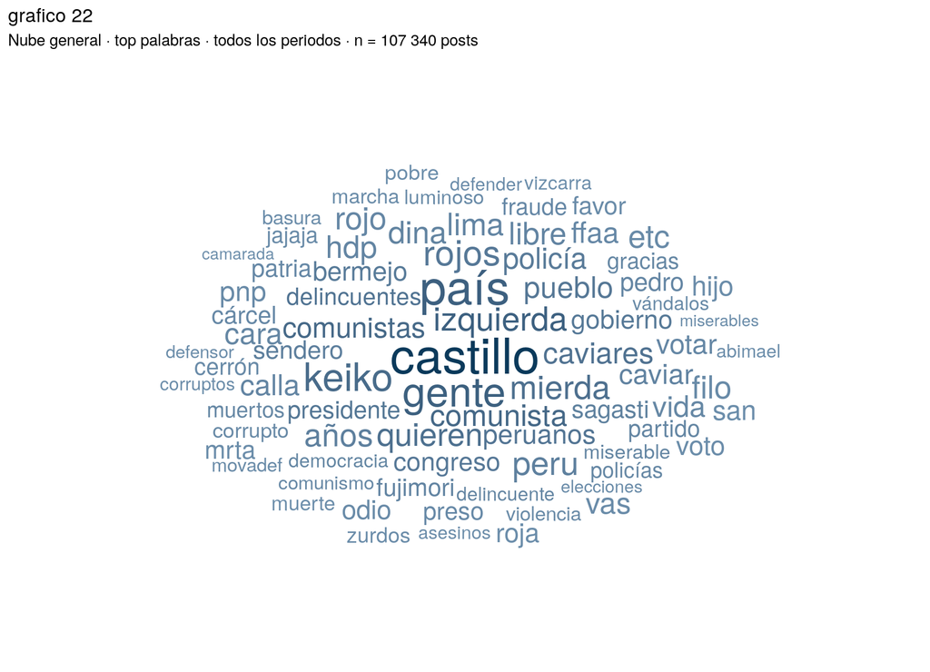

Si juntamos todos los periodos, las palabras que más se repiten alrededor del insulto apuntan a actores políticos: la más frecuente es **castillo**, con 6 231 apariciones.

Se puede ver los datos del gráfico en el siguiente [googlesheet](https://docs.google.com/spreadsheets/d/16uso6iliEZLJt6vQQQ_pPj7w1_HMyRVpd2_49oj4QtU/edit).

## P1 — Elecciones Generales 2016

Rango de fechas: **2016-03-01 a 2016-06-30**. En este periodo hay **6 170** posts (La palabra más frecuente fue **ppk**, con 383 apariciones).

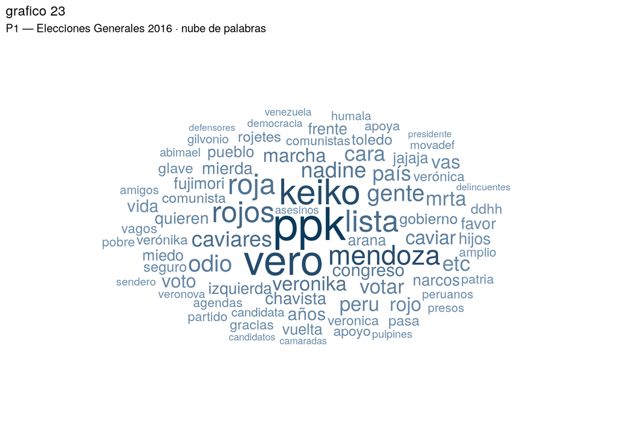

Las tres palabras más frecuentes. En cada una, tres ejemplos (cuentas distintas, las de mayor alcance):

- **ppk** — 383 apariciones
  - [@pedrosiura](https://x.com/pedrosiura): «El apoyo de Verónika Mendoza a #PPK confirma que en el Perú la izquierda nunca ha sido ideológica, sino panfletaria, oportunista y terruca» — [ver post](https://x.com/pedrosiura/status/737434372115173376)
  - [@mardewe](https://x.com/mardewe): «El #Liberador y #Colaborador de terrucos Garcia Sayán pide votar por PPK …tremenda razón para no votar por PPK…» — [ver post](https://x.com/mardewe/status/725951564502851584)
  - [@elhigadodmarita](https://x.com/elhigadodmarita): «Particularmente nunca tuve problema problema con PPK, es más lo apoyé en el 2011, pero hoy con terrucos? Las wiflas! https://t.co/8HftzbJYDC» — [ver post](https://x.com/elhigadodmarita/status/738332923489845248)
- **keiko** — 311 apariciones
  - [@KenjiFujimoriH](https://x.com/KenjiFujimoriH): «Ellos son los que gritan "Keiko nunca más.!..¿Pero acaso gritan TERRORISMO NUNCA MÁS? , ¿o PRO EMERRETISTAS JAMÁS? https://t.co/cizSbwyAbQ» — [ver post](https://x.com/KenjiFujimoriH/status/710550891707891712)
  - [@hectorbecerrilr](https://x.com/hectorbecerrilr): «… d terrucos no detendrá el sentir de millones de peruanos q quieren a Keiko en palacio en Palacio» — [ver post](https://x.com/hectorbecerrilr/status/708630884946202625)
  - [@Cliptomano_](https://x.com/Cliptomano_): «-Me atacan porque soy mujer, como a Keiko -Pero eres hombre -Terruco rojete malnacido, por qué tanto odio!» — [ver post](https://x.com/Cliptomano_/status/738835230962786308)
- **vero** — 310 apariciones
  - [@JBCPERU](https://x.com/JBCPERU): «Vero:"No llevo terrucos en lista". No de los q disparan, pero sí de los q firman pronunciamientos a favor de los terroristas.Casi lo m…» — [ver post](https://x.com/JBCPERU/status/714204826914177025)
  - [@martinhidalgo](https://x.com/martinhidalgo): «- Vero ganó en Cusco. - Es que Cusco está lleno de "terrucos". *Pasan Año Nuevo en Cusco.» — [ver post](https://x.com/martinhidalgo/status/719289677098979332)
  - [@Taconrajon](https://x.com/Taconrajon): «Lo que nadie sabe es que lo que dice la Vero en qechua es "soy terruca, ameos". #debatepresidencial #DebatePeru2016» — [ver post](https://x.com/Taconrajon/status/716809878027767808)

Se puede ver los datos del gráfico en el siguiente [googlesheet](https://docs.google.com/spreadsheets/d/1RhkQS400stoWPlQb-aFvvkBCGLN8ocOE6ckTU8keEXM/edit).

## P2 — Vacancia Merino + paro agrario Ica

Rango de fechas: **2020-11-07 a 2021-01-31**. En este periodo hay **6 232** posts (La palabra más frecuente fue **sagasti**, con 512 apariciones).

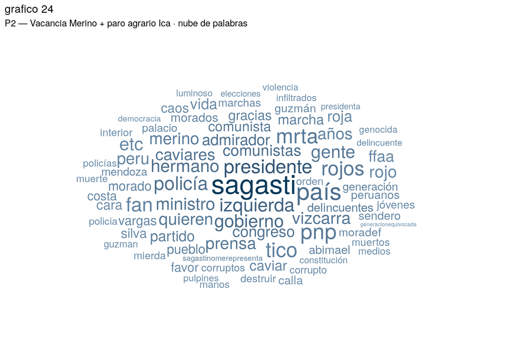

Las tres palabras más frecuentes. En cada una, tres ejemplos (cuentas distintas, las de mayor alcance):

- **sagasti** — 512 apariciones
  - [@elhigadodmarita](https://x.com/elhigadodmarita): «Hoy resulta que Sagasti solo pidió un "certificado de rehén" a un terruco. Decir eso es insultar la inteligencia y capacidad de discernimiento de los per…» — [ver post](https://x.com/elhigadodmarita/status/1328476619909062657)
  - [@margamedonzac](https://x.com/margamedonzac): «Francisco Sagasti admirador del MRTA sería el próximo presidente del Perú, esto es una burla a nuestras Fuerzas Armadas, los millones de muertos en…» — [ver post](https://x.com/margamedonzac/status/1328407150536904707)
  - [@alvarosarco](https://x.com/alvarosarco): «Sagasti no fue a la clausura de la Escuela Naval… Un nuevo desaire a nuestras fuerzas del orden por parte del admirador de Cerpa Cartol…» — [ver post](https://x.com/alvarosarco/status/1339022583610699779)
- **presidente** — 361 apariciones
  - [@Conanacen](https://x.com/Conanacen): «Muchachos, está bien que hayamos tenido de presidente a un delincuente como Vizcarra y que ahora tengamos a uno que admira terrucos, pero de ahí a declarar héroes del Bicentenario a u…» — [ver post](https://x.com/Conanacen/status/1330173103645876225)
  - [@LaSalitadelSin](https://x.com/LaSalitadelSin): «Rosana Cueva al terminar su intervención: Gracias Presidente.😊 (Por dentro: ya te encontraré algo viejo terruco CTM)😡» — [ver post](https://x.com/LaSalitadelSin/status/1333229318508589062)
  - [@alvarosarco](https://x.com/alvarosarco): «Presidente admirador del cerdo de Cerpa Cartolini, el hermano de un cabecilla senderista de ministro y un odio revanchista contra la policía…» — [ver post](https://x.com/alvarosarco/status/1336672801282011136)
- **izquierda** — 292 apariciones
  - [@alvarosarco](https://x.com/alvarosarco): «…en el uso de las armas, entonces queda allanado el camino para que la izquierda capture el poder a través de la turba #TerrorismoNuncaMas» — [ver post](https://x.com/alvarosarco/status/1330371272220545028)
  - [@JulioCaballeroM](https://x.com/JulioCaballeroM): «…encia, tenemos DIVIAC. No tenemos orden dentro de la @PoliciaPeru, la izquierda nos ha secuestrado, hay un emerretista en el gobierno. Conflictos sociales promovidos por la ideología.» — [ver post](https://x.com/JulioCaballeroM/status/1333613758447575045)
  - [@VozLiberal](https://x.com/VozLiberal): «… al vacío. Gracias pulpines. Gracias marchantes y tontos útiles de la izquierda. Gracias prensa basura. Estamos en manos del comunismo pro terruco.» — [ver post](https://x.com/VozLiberal/status/1328094678726696960)

Se puede ver los datos del gráfico en el siguiente [googlesheet](https://docs.google.com/spreadsheets/d/1oCcfkUDLLPyWHKKtbGx_7BBV_eiElHN_7WUovMTMiJY/edit).

## P3 — Elecciones Generales 2021

Rango de fechas: **2021-01-01 a 2021-07-28**. En este periodo hay **31 370** posts (La palabra más frecuente fue **castillo**, con 3 492 apariciones).

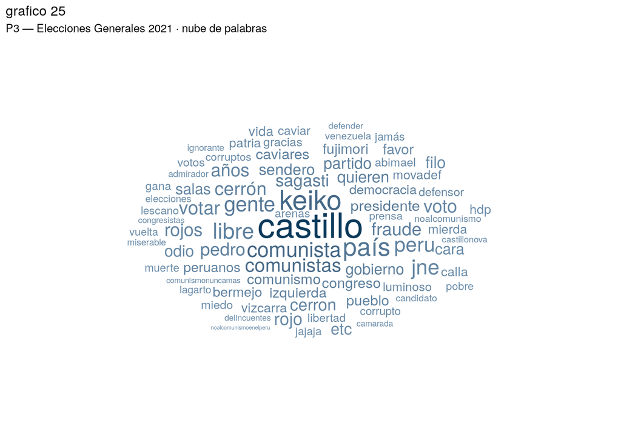

Las tres palabras más frecuentes. En cada una, tres ejemplos (cuentas distintas, las de mayor alcance):

- **castillo** — 3 492 apariciones
  - [@VladimiroMonte6](https://x.com/VladimiroMonte6): «¿Castillo quiere debatir con Alberto Fujimori? El chino pisa el estrado y el profe terruco y Cerrón mojarían los pantalones. No pueden ni c…» — [ver post](https://x.com/VladimiroMonte6/status/1391955796053856257)
  - [@alvarosarco](https://x.com/alvarosarco): «Pedro Castillo y su gente dicen que son víctimas del terruqueo, pero un total de 249 militantes de Perú Libre figuran en el padrón del Movadef (…» — [ver post](https://x.com/alvarosarco/status/1398657968682504192)
  - [@VanyaThais](https://x.com/VanyaThais): «…o que sea el nexo entre el Movimiento Continental Bolivariano y Pedro Castillo, para ejecutar revolución armada? ¿Van a seguir aplazando el juicio de ese terruco?» — [ver post](https://x.com/VanyaThais/status/1397596242436366336)
- **comunista** — 1 716 apariciones
  - [@Mauriciomulder](https://x.com/Mauriciomulder): «Otra mas de Salas Arenas, el mitómano comunista presidente del @JNE_Peru. Liberar a terrucos era su pasion y ahora es autor del FRAUDE electoral. El Congreso debe acusarlo y des…» — [ver post](https://x.com/Mauriciomulder/status/1399553295308541956)
  - [@CiudadanoCae](https://x.com/CiudadanoCae): «10.30 am: "¿Por qué tanto odio?" 10.32 am: "Rojo terruco comunista resentido, ojalá termines prostituyéndote para poder llevar un plato de comida a tu familia, ignorante"» — [ver post](https://x.com/CiudadanoCae/status/1395766330423382017)
  - [@Paul_Brice_Guer](https://x.com/Paul_Brice_Guer): «@erreleon Me estás diciendo que el terruco caviar comunista es democrático….y que la provida, amante de la libertad, impulsora del modeló económico, y respetuosa de la democracia ….no r…» — [ver post](https://x.com/Paul_Brice_Guer/status/1403083259941109761)
- **keiko** — 1 679 apariciones
  - [@elhigadodmarita](https://x.com/elhigadodmarita): «…ta al comunismo, a sus terrucos y demás animalada roja. Yo votaré por Keiko.» — [ver post](https://x.com/elhigadodmarita/status/1400176878334496780)
  - [@alvarosarco](https://x.com/alvarosarco): «Si por antipatía a Keiko terminas votando por el rojo Pedro Castillo y gana la izquierda radical no le estarás haciendo daño a ella sino a ti mismo y a tu…» — [ver post](https://x.com/alvarosarco/status/1389249090442219530)
  - [@LucianoRevoredo](https://x.com/LucianoRevoredo): «Terrucos en Arequipa lanzan piedras a comitiva de Keiko. Ya sabemos que estos animales comunistas son así. ¡Vamos Keiko! Mujer Valiente» — [ver post](https://x.com/LucianoRevoredo/status/1398761333810774019)

Se puede ver los datos del gráfico en el siguiente [googlesheet](https://docs.google.com/spreadsheets/d/12tkp7IKA2yiyVrHhhjeFHnyXK9Ips2djuYcogcJGTY0/edit).

## P4 — Represión protestas del sur

Rango de fechas: **2022-12-07 a 2023-03-31**. En este periodo hay **44 738** posts (La palabra más frecuente fue **castillo**, con 2 132 apariciones).

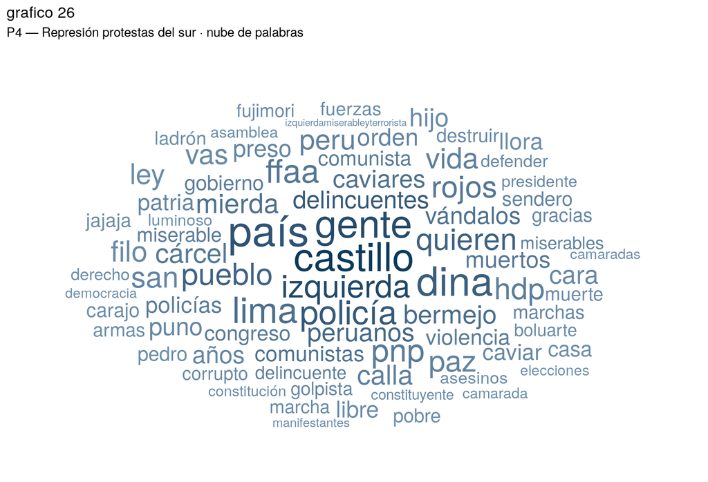

Las tres palabras más frecuentes. En cada una, tres ejemplos (cuentas distintas, las de mayor alcance):

- **castillo** — 2 132 apariciones
  - [@KayMishi](https://x.com/KayMishi): «…ón de Dina Boluarte: "No voy a renunciar" "No voy a ser golpista como Castillo" "Lean su Constitución antes de pedir tonterías" "Ya dejen incendiar el país terrucos de m…" Definitivamente, tuvo más huevos q…» — [ver post](https://x.com/KayMishi/status/1614096757679394819)
  - [@justicierope](https://x.com/justicierope): «…sin turistas por la violencia de Sendero Luminoso. Les dijimos, Pedro Castillo es terruco, voten por Keiko Fujimori; pero no nos hicieron caso. #TerrorismoNuncaMasPeru https://t.co/VGcxyUpPnC» — [ver post](https://x.com/justicierope/status/1624879599522926593)
  - [@Futbolero_Crema](https://x.com/Futbolero_Crema): «… tomado, Puno esta simplemente ardiendo, la culpa de esto es de Pedro Castillo, Anibal Torres y Betssy Chavez nunca se olviden #TerrorismoNuncaMas &lt;#IzquierdaMiserableYTerrorista https://t.co/H1K9GIqMes» — [ver post](https://x.com/Futbolero_Crema/status/1612577511665242112)
- **izquierda** — 1 827 apariciones
  - [@mauargo](https://x.com/mauargo): «… por aceptar 80 soles para salir a "protestar" Murió por creerle a la izquierda. #losmuertossondesigrid #TerrorismoNuncaMas #GorritiNuncaMas» — [ver post](https://x.com/mauargo/status/1619840774069444608)
  - [@LuisPesantes](https://x.com/LuisPesantes): «Mientras la IZQUIERDA destruye el sur, los Cajamarquinos reciben a miles de Turistas para el #Carnaval2023 — Hoteles y hospedajes llenos, agencias turí…» — [ver post](https://x.com/LuisPesantes/status/1627048645878231043)
  - [@FracardTv](https://x.com/FracardTv): «…erú Alza la mano 🙋 si estás de acuerdo que se clausure el MUSEO DE LA IZQUIERDA RADICAL TERRORISTA LLAMADA "Lugar de la Memoria LUM" Los leo! #TerrorismoNuncaMas #LUMNuncaMas https://t.co/WxWkfrsxAm» — [ver post](https://x.com/FracardTv/status/1640872803132948482)
- **gente** — 1 767 apariciones
  - [@alvarosarco](https://x.com/alvarosarco): «…s en actos vandálicos? Por lo menos se debería averiguar qué clase de gente era y en qué circunstancias murieron… Los terroristas no merecen ningún tipo de reparación #TerrorismoNuncaMas» — [ver post](https://x.com/alvarosarco/status/1607359929387556870)
  - [@FASHIONISTA1K](https://x.com/FASHIONISTA1K): «ESTO ES PERÚ, HAY GENTE QUE TRABAJA Y OTROS DESTRUYEN AL QUE TRABAJA! #TerrorismoNuncaMas Dina Boluarte #Willax Keiko Cusco Magaly Panamericana Sur @E_FL…» — [ver post](https://x.com/FASHIONISTA1K/status/1612488058892435456)
  - [@elhigadodmarita](https://x.com/elhigadodmarita): «…RMA de la izquierda e INSTRUMENTO de la derecha. Pregúntate: ¿Por qué gente de "derecha" (García Sayán) liberó a tanto terruco? ¿Por qué gente de "izquierda" elaboró la CVR? ¿Por qué su base ideológica no …» — [ver post](https://x.com/elhigadodmarita/status/1605558364804714497)

Se puede ver los datos del gráfico en el siguiente [googlesheet](https://docs.google.com/spreadsheets/d/1QVi76GztRIdOkHggPGhLU3Ghi6wayTsyYijGTIeZxhg/edit).

## P5 — Protestas Jerí / Trvko

Rango de fechas: **2025-10-15 a 2025-12-31**. En este periodo hay **9 022** posts (La palabra más frecuente fue **mierda**, con 489 apariciones).

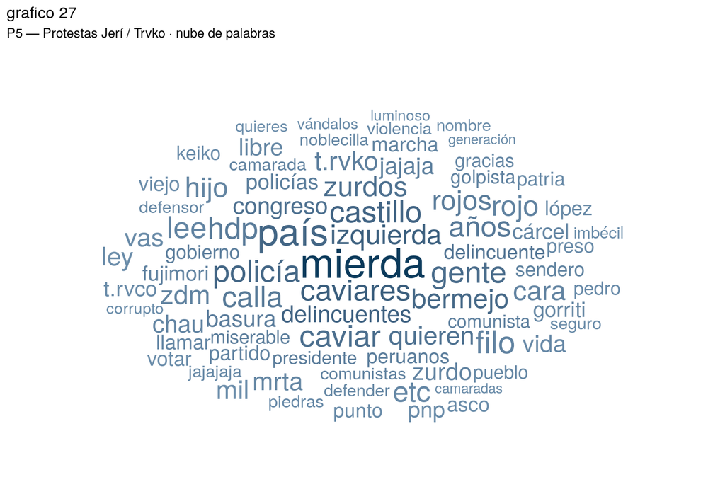

Las tres palabras más frecuentes. En cada una, tres ejemplos (cuentas distintas, las de mayor alcance):

- **mierda** — 489 apariciones
  - [@marselo______](https://x.com/marselo______): «…la policía con la leche de oscar arriola en modo de burla terrucos de mierda las pagarán» — [ver post](https://x.com/marselo______/status/1980324533434450271)
  - [@Pizarrista14](https://x.com/Pizarrista14): «RENUEVA A BARCOS NAVARRO TERRUCO DE MIERDA https://t.co/iAjMAEB9HY» — [ver post](https://x.com/Pizarrista14/status/1996048605204152624)
  - [@parapioggia](https://x.com/parapioggia): «Recuerda ZURD DE MIERDA: este congreso de MIERDA tiene MAYORIA DE IZQUIERDA, porque TU voto digno fue a parar a PERU LIBRE de CERRON y sus camaradas t.ru…» — [ver post](https://x.com/parapioggia/status/1981912365281980863)
- **caviares** — 302 apariciones
  - [@LARESISTENCIA_P](https://x.com/LARESISTENCIA_P): «…a falta alguien así en Palacio En la marcha abundan terrucos, zurdos, caviares y progres: todos violentos y enemigos del Perú #LaResistencia 🇵🇪 https://t.co/AZBRvGLhvC» — [ver post](https://x.com/LARESISTENCIA_P/status/1978684641973268600)
  - [@uterodetitina](https://x.com/uterodetitina): «…drianatudelag por esa ley de cine que "le quito la mermelada" a "esos caviares terrucos". Parece que te seguiremos viendo llorando otros cinco años. Alegría.» — [ver post](https://x.com/uterodetitina/status/2004745516991873223)
  - [@kamahara_lito](https://x.com/kamahara_lito): «…ué otro candidato se saca el polo y se mecha con la prensa mermelera, caviares y terrucos que son el atraso del Perú? ¿ Qué otro candidato ha hechos obras como Porky? ( carreteras, agua potable, hospitales) D…» — [ver post](https://x.com/kamahara_lito/status/1984404108250390741)
- **izquierda** — 297 apariciones
  - [@kamahara_lito](https://x.com/kamahara_lito): «…fue una "avalancha" de aciertos q se están ganando al pueblo Ver a la izquierda gay y terruco destilar bilis, es el mejor regalo el día de hoy https://t.co/KpuPcps6ak» — [ver post](https://x.com/kamahara_lito/status/1988977932182950226)
  - [@AccidentalFuji](https://x.com/AccidentalFuji): «…policía encubierto para lincharlo junto a una turba de terroristas de izquierda, con quienes previamente tiraban piedras a otros policías. https://t.co/Icz8XflAxS» — [ver post](https://x.com/AccidentalFuji/status/1981437720783098061)
  - [@DanteBobadilla](https://x.com/DanteBobadilla): «…jo en el poder. El resto es cuento. Todo lo que quieren es tener a la izquierda en el poder. No se los vamos a permitir. #IzquierdaNuncaMás» — [ver post](https://x.com/DanteBobadilla/status/1978511575326552317)

Se puede ver los datos del gráfico en el siguiente [googlesheet](https://docs.google.com/spreadsheets/d/1d-hOldisb4U37pvYIb-jeG2OET7e2y6hCBOET4nRtbM/edit).

## P6 — Elecciones 2026 — 2ª vuelta

Rango de fechas: **2026-03-01 a 2026-06-07**. En este periodo hay **9 808** posts (La palabra más frecuente fue **keiko**, con 689 apariciones).

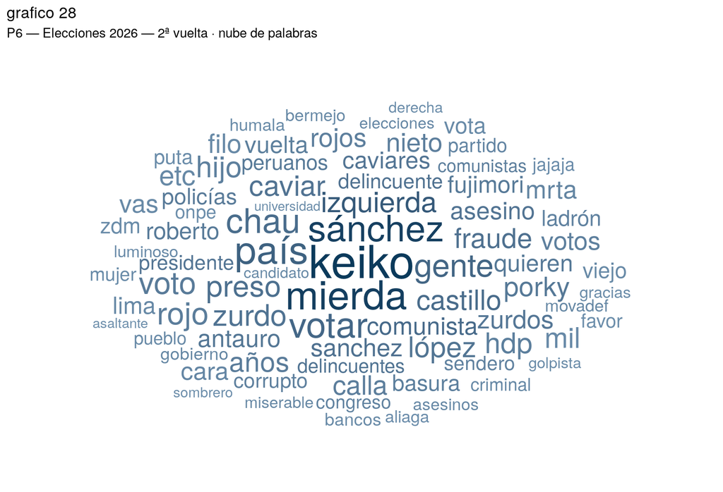

Las tres palabras más frecuentes. En cada una, tres ejemplos (cuentas distintas, las de mayor alcance):

- **keiko** — 689 apariciones
  - [@miilitamercedes](https://x.com/miilitamercedes): «…zamos Nueva Zelanda se viste de Naranja, arrasó con el Tuco Sánchez 🔴 Keiko: 99.88% 🔵 Sánchez: 0.12%» — [ver post](https://x.com/miilitamercedes/status/2063511278040100871)
  - [@MilyJuarezV](https://x.com/MilyJuarezV): «…s terrucos pensamiento Gonzalo. Entonces Sánchez ya no es un peligro, Keiko es el peligro, lejos del mundo multipolar. ¿Así o más claro? https://t.co/iKkT0353Og» — [ver post](https://x.com/MilyJuarezV/status/2054926146043593078)
  - [@Kunturi69](https://x.com/Kunturi69): «…a los rincones màs alejados del Perú y nos liberó de los terroristas. Keiko.. Presidente» — [ver post](https://x.com/Kunturi69/status/2050409482367238438)
- **mierda** — 651 apariciones
  - [@carlpe75](https://x.com/carlpe75): «@larepublica_pe @rmapalacios @ocram Son un ASCO. Pura mierda !!! Deberían ser expatriados ustedes no son peruanos. Un peruano no apoya a terrucos. Cómo puede haber tanto desinformado que sig…» — [ver post](https://x.com/carlpe75/status/2049225171144171730)
  - [@amvaaal](https://x.com/amvaaal): «…nda vuelta, no vuelvan a cometer el mismo error porque nos vamos a la mierda. El futuro de muchos peruanos está en nuestras manos. Aquí veremos por qué es tan importante la educación.» — [ver post](https://x.com/amvaaal/status/2044504377235280061)
  - [@DanteBobadilla](https://x.com/DanteBobadilla): «…s a Porky, quien solo atina a calificar a esas bestias como "gente de mierda", con toda razón. Y resulta que eso afectaría electoralmente a Porky en lugar de afectar a los salvajes de la izquierda castillis…» — [ver post](https://x.com/DanteBobadilla/status/2040419796294988017)
- **sánchez** — 640 apariciones
  - [@miilitamercedes](https://x.com/miilitamercedes): «🔵🔴Ⓜ️ Empezamos Nueva Zelanda se viste de Naranja, arrasó con el Tuco Sánchez 🔴 Keiko: 99.88% 🔵 Sánchez: 0.12%» — [ver post](https://x.com/miilitamercedes/status/2063511278040100871)
  - [@WatameDeLaU](https://x.com/WatameDeLaU): «SÁNCHEZ ROJO TERRUCO CTM NO VAS A PASAR ❌❌❌ SOBRE LA VELITA DEL VISIONARIO CARLOS ESPÁ CON 23% DE LOS VOTOS TOTALES DEL PAÍS NI LLEGAS AÚ…» — [ver post](https://x.com/WatameDeLaU/status/2043536454207308120)
  - [@MilyJuarezV](https://x.com/MilyJuarezV): «Miren a estos terrucos pensamiento Gonzalo. Entonces Sánchez ya no es un peligro, Keiko es el peligro, lejos del mundo multipolar. ¿Así o más claro? https://t.co/iKkT0353Og» — [ver post](https://x.com/MilyJuarezV/status/2054926146043593078)

Se puede ver los datos del gráfico en el siguiente [googlesheet](https://docs.google.com/spreadsheets/d/1KkBMekAM2YzWjMEQSbHupyNk6l2IbZ9MhggGLfZbqqI/edit).

## Frases más usadas

También es interesante poder conocer las frases más usadas alrededor del “terruqueo”. En este caso usamos pares de palabras (bigramas). Se hizo un primer intento de buscar frases más largas (como uan forma de encontrar comportamiento inautentico), pero no se encontraron resultados relevantes.

[interactive chart not shown]

Si juntamos todos los periodos, la frase más repetida es **«pedro castillo»**, con 1 213 apariciones.

Se puede ver los datos del gráfico en el siguiente [googlesheet](https://docs.google.com/spreadsheets/d/1DYKLPYm1wkoi7KR--Y2MF4e9FBzSbDeMvphSCwOaMj0/edit).

### P1 — Elecciones Generales 2016

Rango de fechas: **2016-03-01 a 2016-06-30**. En este periodo hay **6 170** posts (La frase más frecuente fue **«frente amplio»**, con 45 apariciones).

[interactive chart not shown]

Se puede ver los datos del gráfico en el siguiente [googlesheet](https://docs.google.com/spreadsheets/d/1uNwUpQ4mELiGvGmQbwTyHCY0BmS0HL5-65rrZX0ghUo/edit).

### P2 — Vacancia Merino + paro agrario Ica

Rango de fechas: **2020-11-07 a 2021-01-31**. En este periodo hay **6 232** posts (La frase más frecuente fue **«sendero luminoso»**, con 62 apariciones).

[interactive chart not shown]

Se puede ver los datos del gráfico en el siguiente [googlesheet](https://docs.google.com/spreadsheets/d/159IQfBpXAa-DfpttkLshVjICDhc6LcmJ30x3hFBVeS4/edit).

### P3 — Elecciones Generales 2021

Rango de fechas: **2021-01-01 a 2021-07-28**. En este periodo hay **31 370** posts (La frase más frecuente fue **«pedro castillo»**, con 652 apariciones).

[interactive chart not shown]

Se puede ver los datos del gráfico en el siguiente [googlesheet](https://docs.google.com/spreadsheets/d/1UY2hKbG97rpLLWh9BE--wxUYePdJcpjCy0nNrWoKnZc/edit).

### P4 — Represión protestas del sur

Rango de fechas: **2022-12-07 a 2023-03-31**. En este periodo hay **44 738** posts (La frase más frecuente fue **«pedro castillo»**, con 406 apariciones).

[interactive chart not shown]

Se puede ver los datos del gráfico en el siguiente [googlesheet](https://docs.google.com/spreadsheets/d/1LgDEQl__ZMM5FWx3t_RR5K0dOGYYtde0VKXRI9i_Fbg/edit).

### P5 — Protestas Jerí / Trvko

Rango de fechas: **2025-10-15 a 2025-12-31**. En este periodo hay **9 022** posts (La frase más frecuente fue **«pedro castillo»**, con 84 apariciones).

[interactive chart not shown]

Se puede ver los datos del gráfico en el siguiente [googlesheet](https://docs.google.com/spreadsheets/d/1zuWXIoIc3yuZeRx9bT27YwINLNtxdDOtDp51kc86hSY/edit).

### P6 — Elecciones 2026 — 2ª vuelta

Rango de fechas: **2026-03-01 a 2026-06-07**. En este periodo hay **9 808** posts (La frase más frecuente fue **«lópez chau»**, con 177 apariciones).

[interactive chart not shown]

Se puede ver los datos del gráfico en el siguiente [googlesheet](https://docs.google.com/spreadsheets/d/1H6zW7rDSYxF5BkoaKu1ne7rRAcMKg4BA7tuF_uSGK8g/edit).

# 4. Narrativa desinformadora

En esta sección se encuentran solo los posts etiquetados con la regla **DESINFORMACIÓN COMO ARMA** (2 638 publicaciones, 1 533 cuentas).

El prompt de esa regla dice:

> «6. DESINFORMACIÓN COMO ARMA → “Sí”. Narrativas falsas o disputadas usadas para atacar: “Toledo/Paniagua liberaron terroristas” (liberaron a inocentes condenados por jueces sin rostro), “la CIDH libera terrukos”, “Rocío Silva Santisteban alojó a Lori Berenson” (falso). También es “Sí” rotular como “terrucos” a víctimas de ejecuciones del Estado (Barrios Altos, La Cantuta, “Fujimori mató a 7,000, de los cuales 5,900 eran terrukos”).»

Aquí hay tres niveles de análisis:

- Top 20 posts desinformadores por interacción
- Top 5 cuentas desinformadoras por cantidad de publicaciones
- Top 5 cuentas desinformadoras por alcance

## Top 20 posts por interacción

grafico 36 — Top 20 posts (DESINFORMACIÓN COMO ARMA) por likes + respuestas + views

| # | Cuenta | Interacciones | Likes | Respuestas | Views | Post |
| --- | --- | --- | --- | --- | --- | --- |
| 1 | @Ilad_media | 76 169 | 429 | 91 | 75 649 | ver post |
| 2 | @ArequipaAlDia | 56 767 | 1 255 | 354 | 55 158 | ver post |
| 3 | @cesarcombina | 40 000 | 1 799 | 234 | 37 967 | ver post |
| 4 | @TaniaRaimirez | 24 832 | 183 | 180 | 24 469 | ver post |
| 5 | @marita_molina4 | 23 538 | 684 | 62 | 22 792 | ver post |
| 6 | @elhigadodmarita | 19 224 | 210 | 42 | 18 972 | ver post |
| 7 | @CobenasBarrios | 17 953 | 287 | 122 | 17 544 | ver post |
| 8 | @jackymc100 | 15 729 | 642 | 85 | 15 002 | ver post |
| 9 | @SneiderLuz | 11 995 | 573 | 23 | 11 399 | ver post |
| 10 | @eljokerpe | 10 992 | 600 | 27 | 10 365 | ver post |
| 11 | @NellyGracielaO1 | 9 561 | 97 | 19 | 9 445 | ver post |
| 12 | @felix_chipana | 7 844 | 558 | 62 | 7 224 | ver post |
| 13 | @VirgiDArbulu | 7 578 | 213 | 39 | 7 326 | ver post |
| 14 | @JBCPERU | 7 541 | 387 | 11 | 7 143 | ver post |
| 15 | @FinsethMichael | 7 281 | 166 | 12 | 7 103 | ver post |
| 16 | @thelifeofoxa | 7 235 | 426 | 10 | 6 799 | ver post |
| 17 | @lascriticast | 6 803 | 41 | 6 | 6 756 | ver post |
| 18 | @Ilad_media | 6 539 | 312 | 24 | 6 203 | ver post |
| 19 | @JTonyFerna48597 | 6 438 | 373 | 22 | 6 043 | ver post |
| 20 | @subiru2526 | 5 785 | 429 | 23 | 5 333 | ver post |

El post con más interacción en este grupo es de **@Ilad_media**, con 76 169 interacciones.

Se puede ver los datos del gráfico en el siguiente [googlesheet](https://docs.google.com/spreadsheets/d/1T1NcngrRzoxopA8ILKMJJZnPtyRN413m44E-j40XDRA/edit).

## Top 5 cuentas por cantidad de publicaciones

[interactive chart not shown]

grafico 37 — Cuentas con más posts en DESINFORMACIÓN COMO ARMA (con ejemplo)

| # | Cuenta | Posts | Interacciones | Ejemplo |
| --- | --- | --- | --- | --- |
| 1 | @DanielS12576850 | 65 | 22 857 | ver post |
| 2 | @Anchebiondi | 32 | 13 577 | ver post |
| 3 | @gladycilla58 | 27 | 2 762 | ver post |
| 4 | @JoseLuisCordov6 | 24 | 112 | ver post |
| 5 | @DavidChavezBar1 | 21 | 5 879 | ver post |

La cuenta con más publicaciones en esta regla es **@DanielS12576850**, con 65 posts.

Se puede ver los datos del gráfico en el siguiente [googlesheet](https://docs.google.com/spreadsheets/d/19ZIDBpcDFfs2Ip3Sm5O_jDWwhkHh5kYNecct0VHsdLg/edit).

## Top 5 cuentas por alcance

[interactive chart not shown]

grafico 38 — Cuentas con más alcance en DESINFORMACIÓN COMO ARMA (con ejemplo)

| # | Cuenta | Posts | Interacciones | Ejemplo |
| --- | --- | --- | --- | --- |
| 1 | @Ilad_media | 5 | 86 895 | ver post |
| 2 | @ArequipaAlDia | 1 | 56 767 | ver post |
| 3 | @cesarcombina | 1 | 40 000 | ver post |
| 4 | @DanteBobadilla | 19 | 33 336 | ver post |
| 5 | @marita_molina4 | 5 | 25 985 | ver post |

Por alcance, lidera **@Ilad_media**, con 86 895 interacciones acumuladas en esta regla.

Se puede ver los datos del gráfico en el siguiente [googlesheet](https://docs.google.com/spreadsheets/d/1wu6yglcPX7uMRMeVu2sLdjrKfgc-6lxuaLYWkbbK5_Q/edit).

# 5. A qué grupo terruquea la desinformación

Esta sección usa solo los posts del grupo **DESINFORMACIÓN COMO ARMA**.

A partir de la columna `justificacion`, se clasificaron para ver **a qué grupo humano** se dirige el ataque.

Anotación, hay posts que quedan en **Sin grupo humano claro**: casi siempre es la narrativa de la liberación de terroristas sin decir a quién.

Aquí puedes ver la [base de datos con esta nueva clasificación](https://docs.google.com/spreadsheets/d/1anUE-WlHZHhQWnYphZb7IDhltKXRowek4S7xHX1kHxE/edit).

Los grupos, a partir de esos motivos, son estos:

- **Políticos** — candidatos, presidentes, la izquierda, partidos y figuras políticas.
- **Organizaciones y defensores de DDHH** — CIDH, CNDDHH, IDL y defensores de derechos humanos.
- **Víctimas y deudos** — ejecuciones del Estado, Barrios Altos, La Cantuta.
- **Manifestantes** — marchas y manifestantes fallecidos.
- **Prensa** — periodistas y medios.
- **Organizaciones civiles y activistas** — ONG y activistas.
- **Autoridades electorales** — JNE, ONPE y magistrados electorales.
- **Funcionarios públicos** — ministros, funcionarios y otras autoridades.
- **Instituciones de memoria** — CVR y Lugar de la Memoria.
- **Estudiantes y universidades**.
- **Sin grupo humano claro** — el motivo no dice a quién.

Posts de desinformación según el grupo humano al que apunta el motivo

| Grupo | Posts | Participación | Motivo |
| --- | --- | --- | --- |
| Políticos | 1 169 | 44,3% | Usa la narrativa falsa de liberación de terroristas para atacar a un político. |
| Sin grupo humano claro | 452 | 17,1% | Usa la narrativa falsa de que Paniagua liberó terroristas para atacar. |
| Organizaciones y defensores de DDHH | 320 | 12,1% | Usa el término corte terruca para deslegitimar a la CIDH. |
| Víctimas y deudos | 287 | 10,9% | Rotula a víctimas de ejecuciones del Estado como terrucos. |
| Prensa | 88 | 3,3% | Usa la narrativa falsa de vinculación con terroristas para atacar a un periodista. |
| Manifestantes | 81 | 3,1% | Justifica la muerte de manifestantes llamándolos terrucos. |
| Organizaciones civiles y activistas | 71 | 2,7% | Usa desinformación para atacar a una ONG y sus miembros. |
| Autoridades electorales | 70 | 2,7% | Usa la narrativa de defensor de terrucos para atacar a una autoridad electoral. |
| Funcionarios públicos | 50 | 1,9% | Usa la narrativa de defensor de terrucos para atacar a un funcionario público. |
| Instituciones de memoria | 37 | 1,4% | Se ataca a la CVR y al LUM acusándolos de relativizar el terrorismo para deslegitimar su labor de memoria. |
| Estudiantes y universidades | 13 | 0,5% | Estigmatiza a estudiantes universitarios de universidades nacionales asociándolos con el terrorismo. |
| Total | 2 638 | 100,0% | — |

[interactive chart not shown]

**Políticos** concentra 1 169 posts (44,3%). El motivo típico es la narrativa falsa de que se liberó a terroristas, usada contra un político, un candidato o «la izquierda». En las elecciones de 2021 (P3) está el mayor volumen de este grupo.

Las **autoridades electorales** casi solo aparecen en P3: 66 de 70 posts. El motivo repetido es «defensor de terrucos» contra el JNE o un magistrado.

En la represión de las protestas del sur (P4) aparecen otros blancos de ataques: organizaciones y defensores de DDHH (141 de 320), víctimas y deudos (89 de 287) y manifestantes (46 de 81). Ahí el terruqueo niega a muertos y heridos, o deslegitima a quien los defiende.

**Sin grupo humano claro** suma 452 posts. El motivo más repetido de ese resto es la narrativa de que Paniagua liberó terroristas, dicha sin nombrar a quién se ataca.

Dos ejemplos por grupo (cuentas distintas, las de mayor alcance). La frase entre comillas es el motivo del clasificador.

- **Políticos** — 1 169 posts. Motivo más repetido: «Usa la narrativa falsa de liberación de terroristas para atacar a un político.»
  - [@Ilad_media](https://x.com/Ilad_media): «Asesor de campaña de Alfonso López Chau y Exjefe de práctica de la PUCP HACE APOLOGÍA AL T3RR0R1SM0 EN REDES SOCIALES 🚨 Carlos León Moya transmitió a través de su canal de YouTube cómo le rendía culto…» — [ver post](https://x.com/Ilad_media/status/2057975587054985543)
  - [@marita_molina4](https://x.com/marita_molina4): «Duberli Rodríguez, ex presidente del Poder Judicial: "Hay que quemar la Constitución del ’93". Ahora se entiende porque tanto TERRORISTA salió libre y el investigado por TERRORISMO y sentenciado por C…» — [ver post](https://x.com/marita_molina4/status/1628533827189473281)
- **Sin grupo humano claro** — 452 posts. Motivo más repetido: «Usa la narrativa falsa de que Paniagua liberó terroristas para atacar.»
  - [@ArequipaAlDia](https://x.com/ArequipaAlDia): «AREQUIPA.. ojo @FiscaliaPeru @PoliciaPeru.. quien habla aquí, es el médico Jorge del Carpio Lazo, un médico que fue procesado por terrorismo.. este mismo AGITADOR curaba a los terrucos que resultaban …» — [ver post](https://x.com/ArequipaAlDia/status/1608474840100671493)
  - [@CobenasBarrios](https://x.com/CobenasBarrios): «QUE GRAVE EL VIDEO QUE SE HA HECHO VIRAL, DONDE DELIA ESPINOZA RECONOCE SER UNA MRTA Y ANTES CERCANA AL MIR, JAIME DE ALTHAUS SE LO HIZO CONFESAR. UNA TERRUCA SE NOS INFILTRO EN EL MP.» — [ver post](https://x.com/CobenasBarrios/status/1989827259616874693)
- **Organizaciones y defensores de DDHH** — 320 posts. Motivo más repetido: «Usa el término corte terruca para deslegitimar a la CIDH.»
  - [@FinsethMichael](https://x.com/FinsethMichael): «La camarada #Cusi era quien le daba el #TIRO DE GRACIA a las #Victimas Un disparo en la cabeza y listo, así lo admite en declaraciónes a la #DIRCOTE Este es el tipo de gente que defienden las #ONG y l…» — [ver post](https://x.com/FinsethMichael/status/1614636494236303363)
  - [@Ilad_media](https://x.com/Ilad_media): «#ZaGente | ¡ Hacen plata indemnizado terroristas ! El comando Chavín de Huántar, Jean Pierre Jaureguy denunció que existe una red que hace plata liberando e indemnizando a terroristas. Mira el program…» — [ver post](https://x.com/Ilad_media/status/1985174779448463757)
- **Víctimas y deudos** — 287 posts. Motivo más repetido: «Rotula a víctimas de ejecuciones del Estado como terrucos.»
  - [@eljokerpe](https://x.com/eljokerpe): «Los muertos en Juliaca fueron causados por los propios terroristas, porque no tienen heridas de fusil, ni orificios de salida de bala, solo impactos a corta distancia. #TerrorismoNuncaMas» — [ver post](https://x.com/eljokerpe/status/1612842417815949312)
  - [@NellyGracielaO1](https://x.com/NellyGracielaO1): «No le pidan a las #FFAA que salven lo que no supieron cuidar estos 40 años. Juicios cargados de ideología y venganza. Los "idealistas" y sus descendientes en los gobiernos nacionales y provinciales so…» — [ver post](https://x.com/NellyGracielaO1/status/1632453639758311425)
- **Prensa** — 88 posts. Motivo más repetido: «Usa la narrativa falsa de vinculación con terroristas para atacar a un periodista.»
  - [@cesarcombina](https://x.com/cesarcombina): «Que indignante que aun existan negacionistas del terrorismo. Es increible que despues de todo esto sigan con que "no existe Sendero", "no existe la camarada tal", "no existe MOVADEF" … para mi esos …» — [ver post](https://x.com/cesarcombina/status/1624574698494259201)
  - [@lascriticast](https://x.com/lascriticast): «@justicierope Según RMP tienes q pertenecer a una organizacion para ser terrorista eso es FALSO según art 2 y ley 25475 LEE👇 QEPD | Puno | San Isidro | Rosa María Palacios | #TerrorismoNuncaMas https:…» — [ver post](https://x.com/lascriticast/status/1625252196492144650)
- **Manifestantes** — 81 posts. Motivo más repetido: «Justifica la muerte de manifestantes llamándolos terrucos.»
  - [@DanteBobadilla](https://x.com/DanteBobadilla): «¿A alguien le importan los 49 terrucos muertos en la asonada terorrista del sur que pretendía reponer en el poder al asno ladrón Pedro Castillo?» — [ver post](https://x.com/DanteBobadilla/status/2061608357501325678)
  - [@analistaamateur](https://x.com/analistaamateur): «Estoy seguro que si los policías del VRAEM hubieran tenido la oportunidad de defenderse y abatir aunque sea a un terruco, ya los estarían tildando de asesinos y pedirían investigaciones por el pobre c…» — [ver post](https://x.com/analistaamateur/status/1624494630870962177)
- **Organizaciones civiles y activistas** — 71 posts. Motivo más repetido: «Usa desinformación para atacar a una ONG y sus miembros.»
  - [@JorgeDeLama](https://x.com/JorgeDeLama): «Habiendo tanta gente q no es juzgada de manera justa se preocupan solo x los terrucos. Esa orientación hacia ellos te dice claramente la esencia y naturaleza de esa ONG. Tb es feminista y pro género p…» — [ver post](https://x.com/JorgeDeLama/status/1627429985026818054)
  - [@gildatrkovic](https://x.com/gildatrkovic): «¿Sabes quiénes sacaron de la cárcel a terroristas SL MRTA? Paniagua Diego Garcia Sayan choroToledo Gonorritti y su banda IDL ONG terrukas» — [ver post](https://x.com/gildatrkovic/status/1627784704337272832)
- **Autoridades electorales** — 70 posts. Motivo más repetido: «Usa la narrativa de defensor de terrucos para atacar a una autoridad electoral.»
  - [@Mauriciomulder](https://x.com/Mauriciomulder): «Otra mas de Salas Arenas, el mitómano comunista presidente del @JNE_Peru. Liberar a terrucos era su pasion y ahora es autor del FRAUDE electoral. El Congreso debe acusarlo y destituirlo y el PJ debe c…» — [ver post](https://x.com/Mauriciomulder/status/1399553295308541956)
  - [@hg_escorpion](https://x.com/hg_escorpion): «@patriciajaniot Corvetto con el fraude beneficio a los terrucos. https://t.co/yaJAMjkJlk» — [ver post](https://x.com/hg_escorpion/status/2044926624085234030)
- **Funcionarios públicos** — 50 posts. Motivo más repetido: «Usa la narrativa de defensor de terrucos para atacar a un funcionario público.»
  - [@DanteBobadilla](https://x.com/DanteBobadilla): «"Con Merino estaríamos peor" dice Julio Guzmán cuando su gobierno ha tenido que botar tres ministros en tres meses. Uno por terruco y dos por corruptos.» — [ver post](https://x.com/DanteBobadilla/status/1378891706762936322)
  - [@DANPER07049226](https://x.com/DANPER07049226): «@MesiasGuevara @FSagasti Así. Cuántos terroristas se liberaron en el gobierno de Paniagua.? Podrías decirle a todos los peruanos? Eso te parece hacer un buen gobierno? O pregunta a García Sayan , su m…» — [ver post](https://x.com/DANPER07049226/status/1992447894515790066)
- **Instituciones de memoria** — 37 posts. Motivo más repetido: «Se ataca a la CVR y al LUM acusándolos de relativizar el terrorismo para deslegitimar su labor de memoria.»
  - [@TaniaRaimirez](https://x.com/TaniaRaimirez): «El Museo @LUMoficial lleva su nombre en homenaje a Sendero LUMinoso. Eso lo sabemos todos, así que bien serrado ese antro de caviares y terrucos!!» — [ver post](https://x.com/TaniaRaimirez/status/1641114233789202440)
  - [@Licette59473773](https://x.com/Licette59473773): «29/3 Los peruanos respaldamos a la @MuniLima y la Muni de Miraflores por tan honorable hecho.Pedido que hacíamos hace mucho. Era un nido de terrucos. 👇aquí la Patriota Carmen fue llegando en apoyo y l…» — [ver post](https://x.com/Licette59473773/status/1641260840639766529)
- **Estudiantes y universidades** — 13 posts. Motivo más repetido: «Estigmatiza a estudiantes universitarios de universidades nacionales asociándolos con el terrorismo.»
  - [@jungla_insider](https://x.com/jungla_insider): «@pucp @CesarRomeroC Si dejan entrar terrucos indultados por Paniagua para ejercer docencia pero hacen escándalo por qué un puñado de policía utilizaron baños. https://t.co/lmUUTe9bZe» — [ver post](https://x.com/jungla_insider/status/1989844433437884772)
  - [@NDamiano2016](https://x.com/NDamiano2016): «@HarveyColchado Pues te acuerdas que Alberto fujimori los humilló a tus ídolos abimael guzmán reynoso y Víctor polay campos y fue a la UNMSM a sacar a los terroristas de sendero luminoso y borrar la h…» — [ver post](https://x.com/NDamiano2016/status/2055093726712578052)